# Act Report

## Michael Mosin

#### 415-468 word written report that communicates the insights and displays the visualizations produced from my wrangled data.

Hello! Welcome to my WeRateDogs Twitter Data Wrangling Project. My name is Michael Mosin, and I have worked very hard on getting this data cleaned and worthy of analysis. Below are some of my assessments and associated visuals.

My variables of interest were dog types, ratings, count of favorites, and count of retweets.

### Assessment of Dogtionary Dog Type Usage in Tweet Text

#### Insight:

It appears that when WeRateDogs does decide to describe dogs using Dogtionary nomenclature, the most common instances of doing so are for describing the smallest / youngest of dogs. This does not necessarily determine whether the majority of WeRateDog tweets are of 'puppers,' however, there is a greater chance of that being the case.

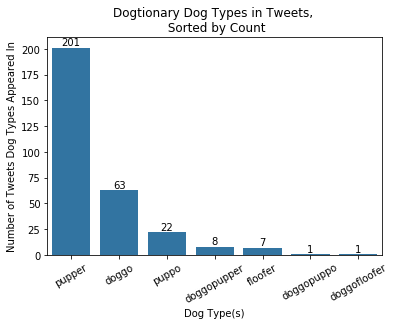

```python
# Reference: https://stackoverflow.com/questions/32891211/limit-the-number-of-groups-shown-in-seaborn-countplot
ax = sns.countplot(data = df, x ='dog_type',
                  color = sns.color_palette()[0],
                  order=df.dog_type.value_counts().index);
plt.xticks(rotation=30)
plt.title('Dogtionary Dog Types in Tweets, \n Sorted by Count')
ax.set_xlabel('Dog Type(s)')
ax.set_ylabel('Number of Tweets Dog Types Appeared In')

#Reference: https://stackoverflow.com/questions/39519609/annotate-bars-with-values-on-pandas-on-seaborn-factorplot-bar-plot
for p in ax.patches:
    ax.annotate('{:.0f}'.format(p.get_height()),
                (p.get_x() + p.get_width() / 2.,
                 p.get_height()+2),
                ha='center')
```

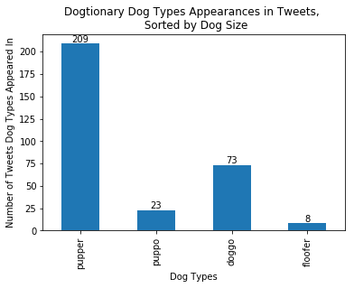

```python
# Reference: https://stackoverflow.com/questions/41801419/drawing-bar-charts-from-boolean-fields
df1 = df[['pupper','puppo','doggo','floofer']].apply(pd.value_counts)
ax = df1.loc[True].plot.bar();

plt.title('Dogtionary Dog Types Appearances in Tweets, \n Sorted by Dog Size')
ax.set_xlabel('Dog Types')
ax.set_ylabel('Number of Tweets Dog Types Appeared In')

for p in ax.patches:
    ax.annotate('{:.0f}'.format(p.get_height()),
                (p.get_x() + p.get_width() / 2.,
                 p.get_height()+2),
                ha='center')
```

### Assessment of Averaged Ratings in Dataset

#### Insight:

Outside of a few outliers way out to the right, the general distribution of averaged ratings is left-skewed, with the densest ratings having the numerator value of 10-13. It is interesting to see that, despite the WeRateDogs Twitter account having a trademark of giving out ratings of 10 or greater, they still fairly often give out ratings below 10.

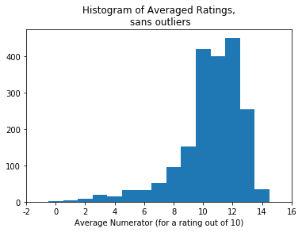

```python
df['avg_rating'] = df.rating_numerator / df.rating_denominator

bins = np.arange(-.25, df.avg_rating.max()+0.25, 0.1)
ax = plt.hist(df.avg_rating, bins = bins)

plt.xlim([-0.05,1.5])
locs, labels = plt.xticks()
plt.xticks(locs, (locs*10).astype('int64'));

plt.title('Histogram of Averaged Ratings,\n sans outliers')
plt.xlabel('Average Numerator (for a rating out of 10)');
```

### Assessment of Favorite Counts vs Retweet Counts

#### Insight:

It appears that, although 'favorite_count' and 'retweet_count' have a quite high positive correlation (r = 0.913), there is also demonstrable heteroscedasticity.

```python
df[['favorite_count','retweet_count']].corr()
```

|  | favorite_count | retweet_count |
| --- | --- | --- |
| favorite_count | 1.000000 | 0.913012 |
| retweet_count | 0.913012 | 1.000000 |

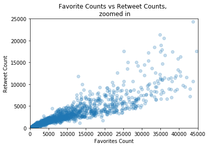

```python
plt.scatter(df.favorite_count, df.retweet_count, alpha = .25)
plt.xlim([0,45000])
plt.ylim([0,25000])
plt.title('Favorite Counts vs Retweet Counts, \n zoomed in')
plt.xlabel('Favorites Count');
plt.ylabel('Retweet Count');
```